# Learning activity - Bayesian Data Analysis

Eva Ascarza and Tian Zheng

December 21, 2015

In this learning activity, we will first simulate some customer behavior data according to a model and then we will use Bayesian modeling and `rstan` to model the simulated data. Simulation is a great way of learning about how a method works.

If you have not done so already, you need to first install `rstan` by typing `install.packages("rstan"")` in your console windown (lower left panel in Rstudio).

```r
require(rstan)
rstan_options(auto_write = TRUE)
options(mc.cores = parallel::detectCores()-2)
```

### Simulate the data

We will simulate a data set with 5000 invidiuals drawn from a population of musume members. Among museum members,

- $X_1$ `gender`: Approximately 60% are females.
- $X_2$ `fotography`: 50% expressed interest for fotography.
- $X_3$ `sculpture`:30% expressed interest for sculpture.
- $X_4$ `digital_content`: The average number of digital contents consumed by the members is 0.5.
- $X_5$ `months_since`: The average length since last visit is 5 months.

```r
N <- 5000
# we assume 5000 members
female <- rbinom(N,1,0.6)
# simulate 60% of female
fotography <- rbinom(N,1,0.5)
# simulate 50% of customers who expressed interest for fotography
sculpture <- rbinom(N,1,0.3)
# simulate 50% of customers who expressed interest for sculpture
digital_content <- rpois(N,0.5)
# simulate digital content
months_since <- rpois(N,5)
# simulate months since last visit, with a max of 12
months_since[months_since>12] <- 12
```

### simulate renewal behavior and prepare the data

We are interested in whether these members will renew their membership. $Y$ (`renewal`) equals 1 if the member decides to renew, 0 otherwise. We assume the following [probit model](https://en.wikipedia.org/wiki/Probit_model) for Y given X.

$$P(Y=1 | X_1, X_2, X_3, X_4, X_5) = \Phi(\beta_0 +\beta_1 X_1 +\beta_2 X_2 + \beta_3 X_3 +\beta_4 X_4 + \beta_5 X_5)$$
where $\Phi(\cdot)$ is the [cumulative distribution function (CDF)](https://en.wikipedia.org/wiki/Cumulative_distribution_function) of the standard normal distribution.

```r
beta0 <- 0.6
beta1 <- 0.9
beta2 <- 0.6
beta3 <- 0.01
beta4 <- -0.01
beta5 <- -0.2

prob_simul <- pnorm(beta0 + beta1*female + beta2*fotography + beta3*sculpture + beta4*digital_content + beta5*months_since)
renewal <- rbinom(N,1,prob_simul)
```

### Prepare data for Stan

We first create an X matrix that combines all the input variables, including a column corresponding to the intercept. `cbind` is the `R` command for combining vectors as columns.

```r
X <- cbind(rep(1,N),
           female,
           fotography,
           sculpture,
           digital_content,
           months_since)

# assign column names
colnames(X) <- c("intercept",
                 "female",
                 "fotography",
                 "sculpture",
                 "digital_content",
                 "months_since")
K<-dim(X)[2]
```

### Code for Stan

`stan` uses a specific modeling syntax. It requires the specification of the types of data and parameters, in addition to model statements.

```r
probit <- '
data{
  int<lower=0> N; # number of observations
  int<lower=0> K; # number of parameters

  int<lower=0,upper=1> y[N];
  vector[K] X[N];
}
parameters{
  vector[K] beta;
}
model{
  beta ~ cauchy(0,5);

for(j in 1:N)
  y[j] ~ bernoulli(Phi_approx(dot_product(X[j],beta)));
}
'
```

### Run STAN

The initialization step of `stan` may take a little while but the running time should be just a couple of minuets.

```r
data_list <- list(N=N,K=K,y=renewal,X=X)
fit <- stan(model_code=probit,
            data=data_list,
            warmup=2000,
            iter=4000,
            chains=2)
```

[output not shown]

### SUMMARY of restuls

In the summary of output, the posterior distribution for each model coefficient is summaried using its percentiles.

```r
print(fit)
```

```
## Inference for Stan model: cf5de9320c057d6ba79f5297d8079d34.
## 2 chains, each with iter=4000; warmup=2000; thin=1;
## post-warmup draws per chain=2000, total post-warmup draws=4000.
##
##             mean se_mean   sd     2.5%      25%      50%      75%    97.5%
## beta[1]     0.56    0.00 0.06     0.44     0.52     0.56     0.59     0.67
## beta[2]     0.92    0.00 0.04     0.84     0.89     0.92     0.94     1.00
## beta[3]     0.68    0.00 0.04     0.61     0.65     0.68     0.71     0.76
## beta[4]    -0.01    0.00 0.04    -0.09    -0.04    -0.01     0.02     0.07
## beta[5]     0.03    0.00 0.03    -0.03     0.01     0.03     0.04     0.08
## beta[6]    -0.21    0.00 0.01    -0.23    -0.21    -0.21    -0.20    -0.19
## lp__    -2683.93    0.04 1.68 -2688.07 -2684.81 -2683.63 -2682.71 -2681.62
##         n_eff Rhat
## beta[1]  2685    1
## beta[2]  3679    1
## beta[3]  4000    1
## beta[4]  4000    1
## beta[5]  4000    1
## beta[6]  3073    1
## lp__     1971    1
##
## Samples were drawn using NUTS(diag_e) at Fri Oct 14 19:25:34 2016.
## For each parameter, n_eff is a crude measure of effective sample size,
## and Rhat is the potential scale reduction factor on split chains (at
## convergence, Rhat=1).
```

```r
fitlist <- extract(fit)
```

#### Convergence

Convergence plots show whether the draws from posterior distributions are well mixed together.

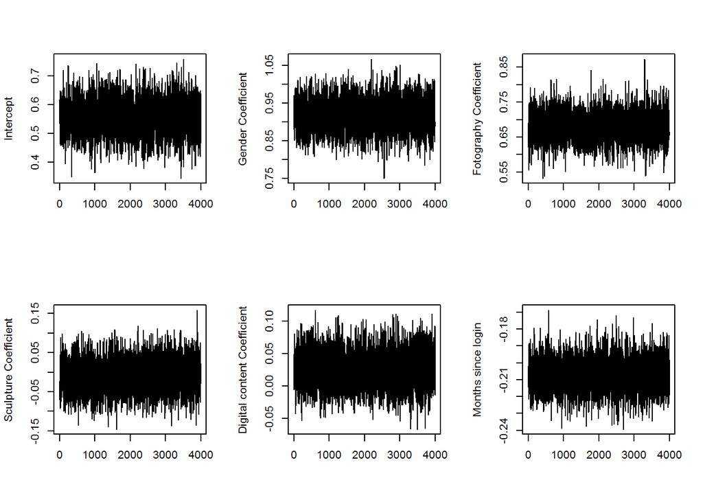

```r
par(mfrow=c(2,3))
plot(fitlist$beta[,1],type="l",xlab="",ylab="Intercept")
plot(fitlist$beta[,2],type="l",xlab="",ylab="Gender Coefficient")
plot(fitlist$beta[,3],type="l",xlab="",ylab="Fotography Coefficient")
plot(fitlist$beta[,4],type="l",xlab="",ylab="Sculpture Coefficient")
plot(fitlist$beta[,5],type="l",xlab="",ylab="Digital content Coefficient")
plot(fitlist$beta[,6],type="l",xlab="",ylab="Months since login")
```

#### Histograms of posterior distributions

Posterior distributions of model coefficients.

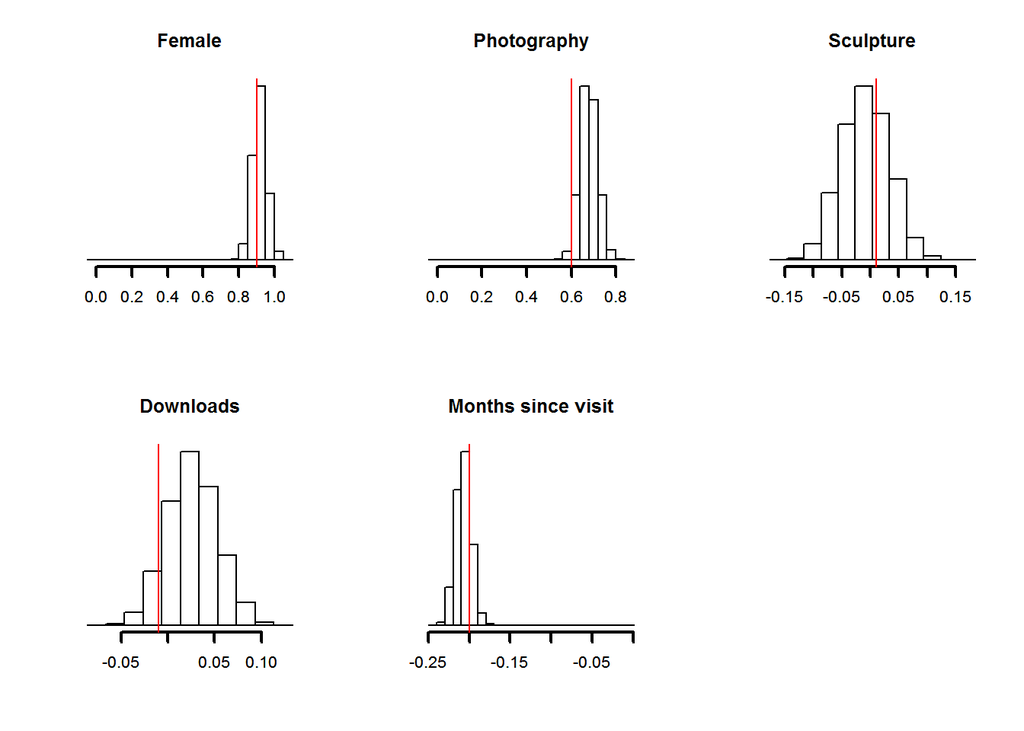

```r
par(mfrow=c(2,3))
par(bg="white", fg="black",
    col.lab="black", col.axis="black",
    col.main="black", lwd=1)
#Gender
param <- fitlist$beta[,2]
min <- min(0,min(param))
max <- max(0,max(param))
hist(param,breaks=seq(min-0.05,max+0.05,0.05),main="Female",xlab="", ylab="",yaxt='n')
axis(1, lab=T , lwd=2)
abline(v=beta1, col=2)
#PHOTO
param <- fitlist$beta[,3]
min <- min(0,min(param))
max <- max(0,max(param))
hist(param,breaks=seq(min-0.04,max+0.04,0.04),main="Photography",xlab="", ylab="",yaxt='n')
axis(1, lab=T , lwd=2)
abline(v=beta2, col=2)
#SCULPTURE
param <- fitlist$beta[,4]
min <- min(0,min(param))
max <- max(0,max(param))
hist(param,breaks=seq(min-0.03,max+0.03,0.03),main="Sculpture",xlab="", ylab="",yaxt='n')
axis(1, lab=T , lwd=2)
abline(v=beta3, col=2)
#ONLINE CONTENT
param <- fitlist$beta[,5]
min <- min(0,min(param))
max <- max(0,max(param))
hist(param,breaks=seq(min-0.02,max+0.02,0.02),main="Downloads",xlab="", ylab="",yaxt='n')
axis(1, lab=T , lwd=2)
abline(v=beta4, col=2)
#VISIT
param <- fitlist$beta[,6]
min <- min(0,min(param))
max <- max(0,max(param))
hist(param,breaks=seq(min-0.01,max+0.01,0.01),main="Months since visit",xlab="", ylab="",yaxt='n')
axis(1, lab=T , lwd=2)
abline(v=beta5, col=2)
```